# ATLANTA US PEN

# ICE Detention Facility Statistical Report

*Data as of June 23, 2025 - Using Interval ADP Calculations*

[*Back to Detention Reports*](https://detentionreports.com/)

## Key Statistics

[output not shown]

## Facility Location

[interactive chart not shown]

[🗺️ View Interactive Map](https://maps.google.com/maps?q=33.709503,-84.365903) [🧭 Get Directions](https://www.google.com/maps/dir//33.709503,-84.365903)

## Interval Average Daily Population (Interval ADP)

This is a backward moving average calculation of facility populations based on ICE data. For more information, see the background paper [here](https://relevant-research.com/work).

[figure not shown]

## Interval ADP by Detainee Classification

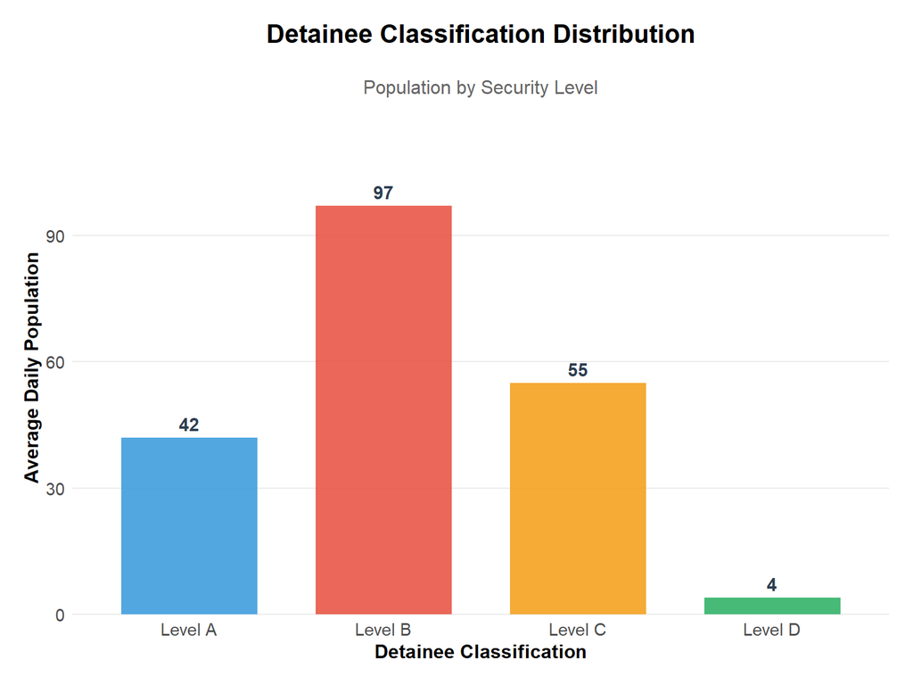

ICE defines these classifications as follows:

*Upon admission and periodically thereafter, detainees are categorized into a security level based on a variety of public safety factors, and are housed accordingly.*

*Factors include prior convictions, threat risk, disciplinary record, special vulnerabilities, and special management concerns.*

*Detainees are categorized into one of four classes of security risk:*

- *A/low*
- *B/medium low*
- *C/medium high*
- *D/high*

Due to rounding, summing the Security Classification totals may not equal the facility’s aggregate Interval ADP.

## Interval ADP by Gender and Criminal Status

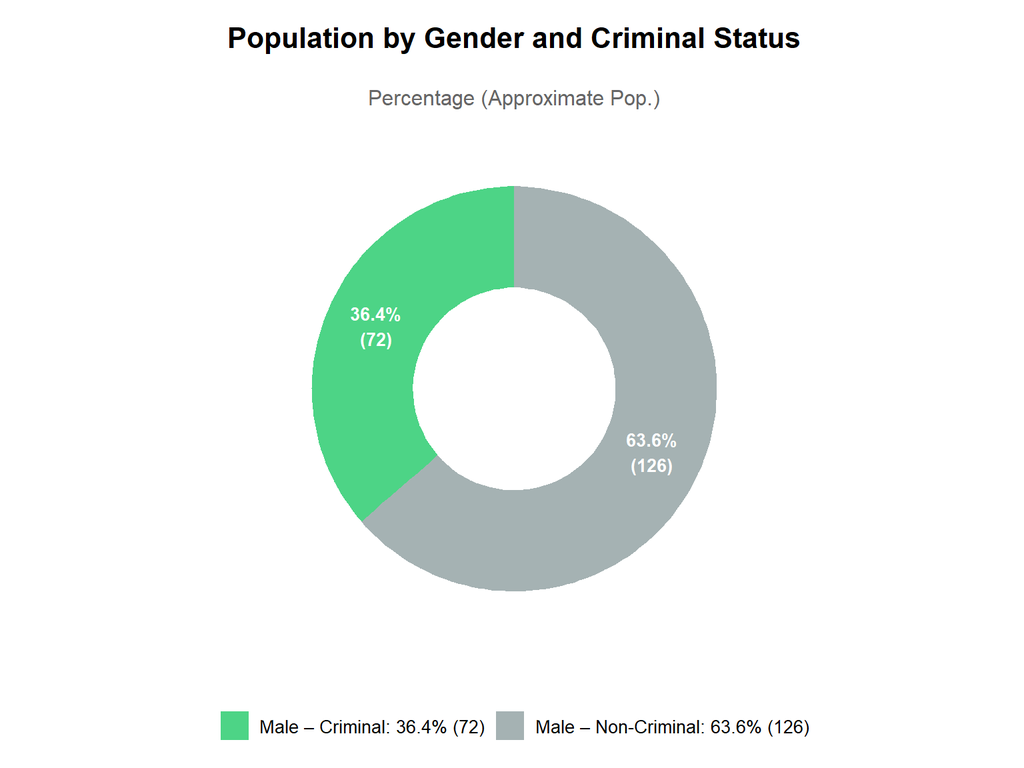

ICE defines criminality as follows:

- *Convicted Criminal:*
  - *Immigration Violators with a criminal conviction entered into ICE systems of record at the time of ICE custody.*
- *Pending Criminal Charges:*
  - *Immigration Violators with pending criminal charges entered into ICE system of record at the time of ICE custody.*
- *Other Immigration Violators:*
  - *Immigration Violators without any known or a criminal conviction, or pending charges entered into ICE system of record at the time of ICE custody.*

Due to rounding, summing the Gender and Criminal Status totals may not equal the facility’s aggregate Interval ADP.

[*Back to Detention Reports*](https://detentionreports.com/)

*Report generated on July 28, 2025 using ICE Integrated Decision Support (IIDS) interval ADP data from June 23, 2025*

Developed by [Relevant Research](https://relevant-research.com/)